# Linear Regression

```r
knitr::opts_chunk$set(echo = T, include = T, wwarning = F)
```

## Boston data

Boston is a database with information of areas around Boston city, and the median house prices. It is included in the MASS R package. The essential data manipulation will be performed with the tidyverse collection of R packages.

```r
library(MASS)
library(tidyverse)
library(gridExtra)
library(broom)
```

We will use linear regression to infer the relationship between the percentage of lower status of the population (lstat) and house prices (medv).

## First linear regression model

Fit of the basic linear regression model using lm function.

```r
fit1 <- lm(medv ~ lstat, data = Boston)
summary(fit1)
```

```
##
## Call:
## lm(formula = medv ~ lstat, data = Boston)
##
## Residuals:
##     Min      1Q  Median      3Q     Max
## -15.168  -3.990  -1.318   2.034  24.500
##
## Coefficients:
##             Estimate Std. Error t value Pr(>|t|)
## (Intercept) 34.55384    0.56263   61.41   <2e-16 ***
## lstat       -0.95005    0.03873  -24.53   <2e-16 ***
## ---
## Signif. codes:  0 '***' 0.001 '**' 0.01 '*' 0.05 '.' 0.1 ' ' 1
##
## Residual standard error: 6.216 on 504 degrees of freedom
## Multiple R-squared:  0.5441, Adjusted R-squared:  0.5432
## F-statistic: 601.6 on 1 and 504 DF,  p-value: < 2.2e-16
```

## Diagnostics

We need to check several assumptions:

- Constant variance of errors
- Normal errors
- Model structure

### Constant variance of errors

Let’s plot the residuals vs. the fitted values. Constant symmetrical variation (homoschedasticity) should be observed in the vertical direction (A). Another possibility is to plot the square root of the absolute values of the residuals (B).

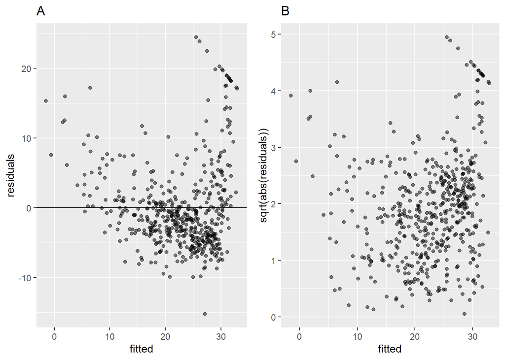

```r
df1 <- data.frame(residuals = fit1$residuals,
                  sqrt_abs_residuals = sqrt(abs(fit1$residuals)),
                  fitted = fit1$fitted.values)
p1 <- ggplot(data = df1, aes(x = fitted, y = residuals)) +
  geom_hline(yintercept = 0) +
  geom_point(alpha = 0.5) +
  labs(x = "fitted",
       y = "residuals",
       title = "A")

p2 <- ggplot(data = df1, aes(x = fitted, y = sqrt_abs_residuals)) +
  geom_point(alpha = 0.5) +
  labs(x = "fitted",
       y = "sqrt(abs(residuals))",
       title = "B")

grid.arrange(p1, p2,  ncol = 2)
```

### Normal errors

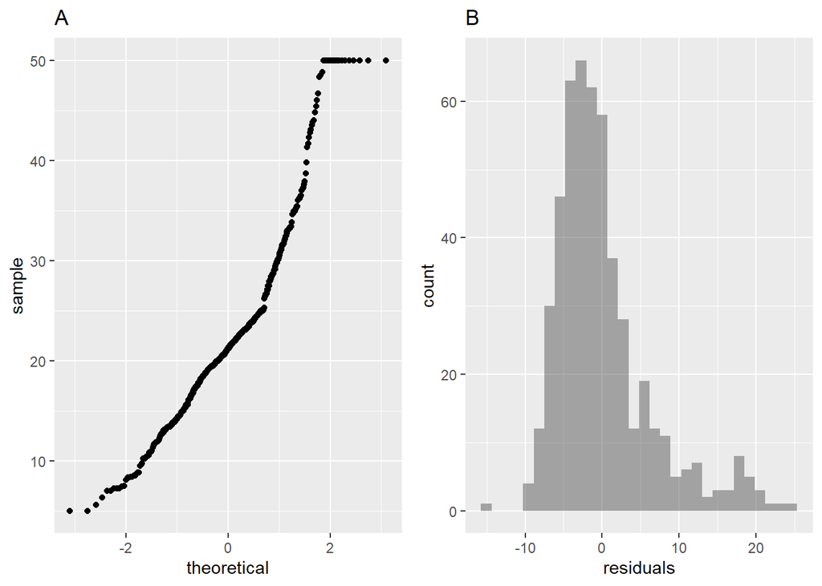

```r
df1 <- data.frame(residuals = fit1$residuals,
                  sqrt_abs_residuals = sqrt(abs(fit1$residuals)),
                  fitted = fit1$fitted.values)
p1 <- ggplot(data = Boston, aes(sample = medv)) +
  stat_qq() +
  labs(title = "A")

p2 <- ggplot(data = df1, aes(x = residuals)) +
  geom_histogram(alpha = 0.5) +
  labs(x = "residuals",
       title = "B")

grid.arrange(p1, p2,  ncol = 2)
```

### Model structure

Check the relationship between the dependent variable (y-axis) and independent variable (x-axis). The regression line is added.

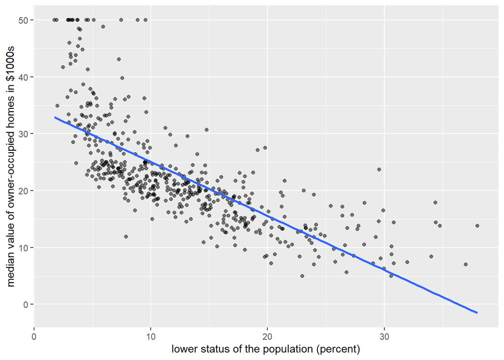

```r
ggplot(data = Boston, aes(x = lstat, y = medv)) +
  geom_point(alpha=0.5) +
  geom_smooth(method = "lm", se = F) +
  labs(x="lower status of the population (percent)",
       y="median value of owner-occupied homes in $1000s")
```

Add an higher-order term (quadratic).

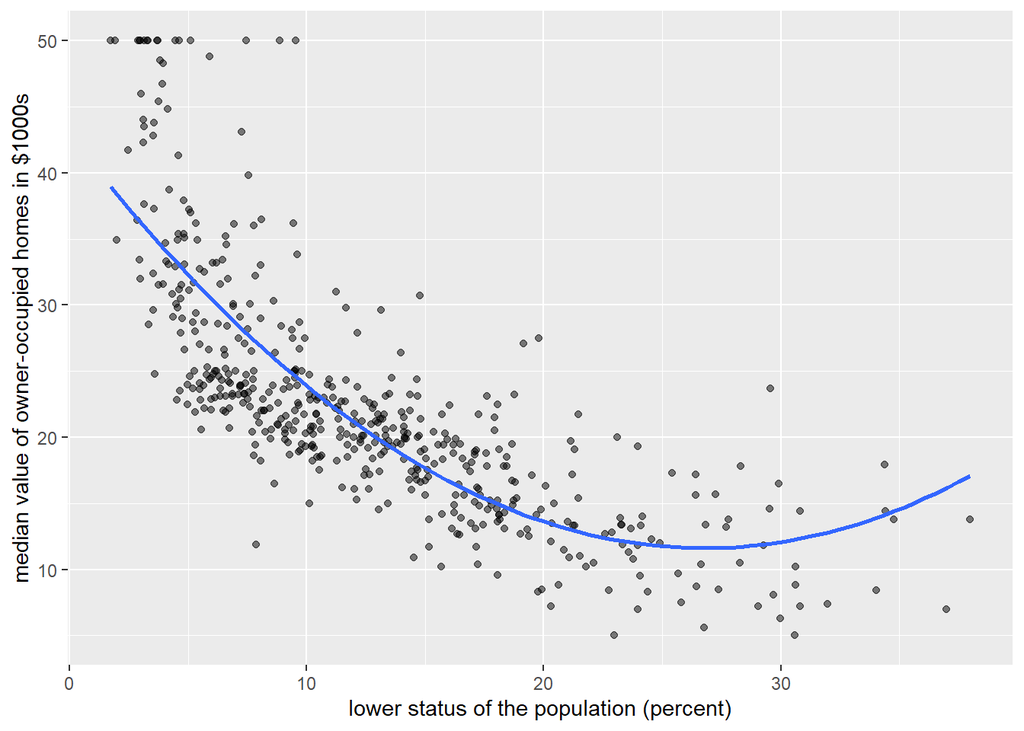

```r
ggplot(data = Boston, aes(x = lstat, y = medv)) +
  geom_point(alpha=0.5) +
  geom_smooth(method = "lm", formula = y ~ x + I(x^2), se = F) +
  labs(x="lower status of the population (percent)",
       y="median value of owner-occupied homes in $1000s")
```

Evaluate the results of the linear regression with the quadratic term.

```r
fit2 <- lm(medv ~ lstat + I(lstat^2), data = Boston)
summary(fit2)
```

```
##
## Call:
## lm(formula = medv ~ lstat + I(lstat^2), data = Boston)
##
## Residuals:
##      Min       1Q   Median       3Q      Max
## -15.2834  -3.8313  -0.5295   2.3095  25.4148
##
## Coefficients:
##              Estimate Std. Error t value Pr(>|t|)
## (Intercept) 42.862007   0.872084   49.15   <2e-16 ***
## lstat       -2.332821   0.123803  -18.84   <2e-16 ***
## I(lstat^2)   0.043547   0.003745   11.63   <2e-16 ***
## ---
## Signif. codes:  0 '***' 0.001 '**' 0.01 '*' 0.05 '.' 0.1 ' ' 1
##
## Residual standard error: 5.524 on 503 degrees of freedom
## Multiple R-squared:  0.6407, Adjusted R-squared:  0.6393
## F-statistic: 448.5 on 2 and 503 DF,  p-value: < 2.2e-16
```

The $R^2$ increased to 0.64. Let’s check the constant variance of errors now.

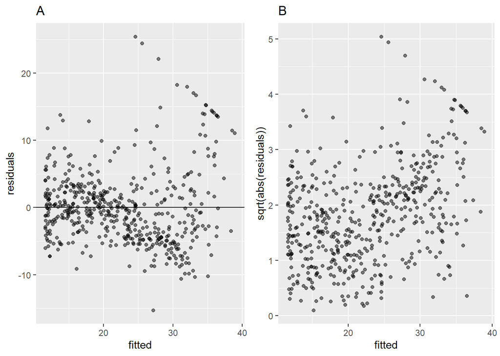

```r
df2 <- data.frame(residuals = fit2$residuals,
                  sqrt_abs_residuals = sqrt(abs(fit2$residuals)),
                  fitted = fit2$fitted.values)
p1 <- ggplot(data = df2, aes(x = fitted, y = residuals)) +
  geom_hline(yintercept = 0) +
  geom_point(alpha = 0.5) +
  labs(x = "fitted",
       y = "residuals",
       title = "A")

p2 <- ggplot(data = df2, aes(x = fitted, y = sqrt_abs_residuals)) +
  geom_point(alpha = 0.5) +
  labs(x = "fitted",
       y = "sqrt(abs(residuals))",
       title = "B")

grid.arrange(p1, p2,  ncol = 2)
```

## Interaction

Let’s see how interaction works adding the chas variable (1 if tract bounds river; 0 otherwise).

```r
fit3 <- lm(medv ~ lstat*factor(chas), data = Boston)
summary(fit3)
```

```
##
## Call:
## lm(formula = medv ~ lstat * factor(chas), data = Boston)
##
## Residuals:
##     Min      1Q  Median      3Q     Max
## -14.657  -3.787  -1.289   1.644  24.953
##
## Coefficients:
##                     Estimate Std. Error t value Pr(>|t|)
## (Intercept)         33.76716    0.57018  59.222  < 2e-16 ***
## lstat               -0.91498    0.03897 -23.478  < 2e-16 ***
## factor(chas)1        9.82513    2.10320   4.672 3.84e-06 ***
## lstat:factor(chas)1 -0.43288    0.16017  -2.703  0.00711 **
## ---
## Signif. codes:  0 '***' 0.001 '**' 0.01 '*' 0.05 '.' 0.1 ' ' 1
##
## Residual standard error: 6.057 on 502 degrees of freedom
## Multiple R-squared:  0.5688, Adjusted R-squared:  0.5663
## F-statistic: 220.8 on 3 and 502 DF,  p-value: < 2.2e-16
```

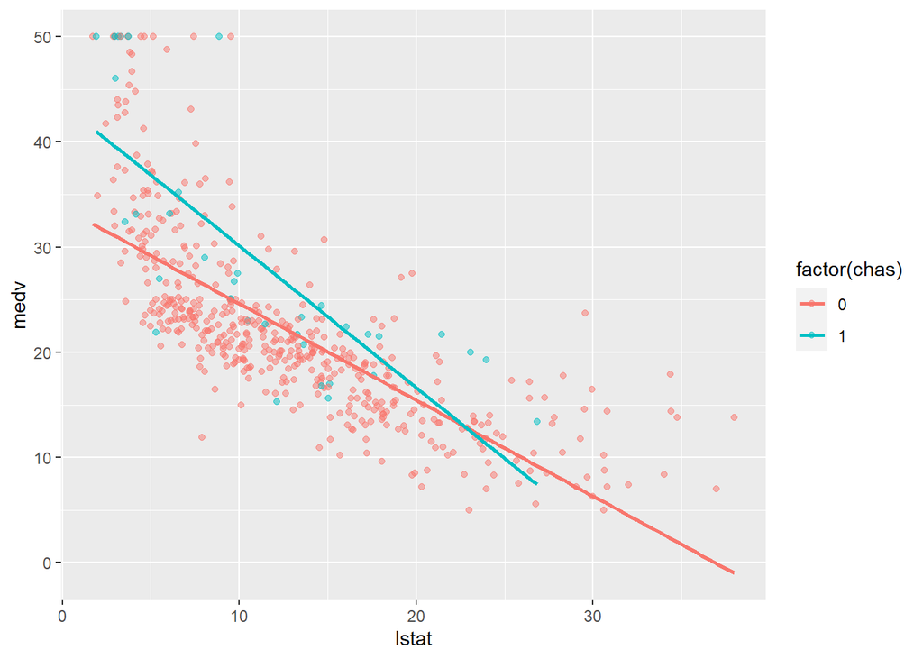

```r
ggplot(data = Boston, aes(x = lstat, y = medv, color = factor(chas))) +
  geom_point(alpha = 0.5) +
  geom_smooth(method = "lm", se = F)
```

## Resources

https://en.wikipedia.org/wiki/Markdown

http://faculty.cas.usf.edu/mbrannick/regression/Part3/Reg2IVMatrix.html

http://www.stat.columbia.edu/~fwood/Teaching/w4315/Fall2009/lecture_11

https://www.r-bloggers.com/2014/04/checking-glm-model-assumptions-in-r/